# Introduction to vocc

CJ Brown

2018-02-26

# Introduction to the vocc package

This package contains functions for calculating the VoCC based on: Functions based on [Burrows MT, Schoeman DS, Buckley LB, Moore P, Poloczanska ES, Brander KM, Brown C, Bruno JF, Duarte CM, Halpern BS, Holding J. The pace of shifting climate in marine and terrestrial ecosystems. Science. 2011 Nov 4;334(6056):652-5.](http://science.sciencemag.org/content/334/6056/652).

## Simple guide to calculating the VoCC

First load the test version of the package and a raster-brick of sea surface temperature data derived from the [HadISST](https://www.metoffice.gov.uk/hadobs/hadisst/data/download.html) database:

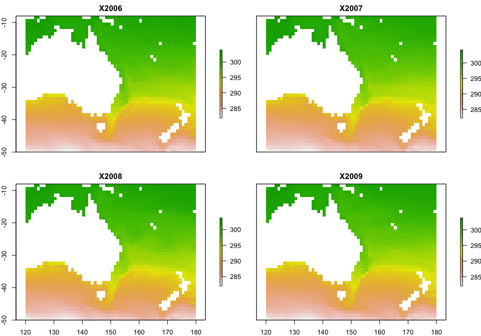

```r
library(vocc)
data(sst)
plot(sst, 1:4)
```

Then calculate the trend per pixel:

```r
slopedat <- calcslope(sst)
```

Then get the mean temperature for a time period and calculate the spatial gradient:

```r
allyears <- rep(1, nlayers(sst))
mnsst <- stackApply(sst, indices = allyears, fun = mean)
spatx <- spatialgrad(mnsst)
```

Now we can calculate the VoCC:

```r
velodf <- calcvelocity(spatx, slopedat)
```

Mapping it again is straightforward:

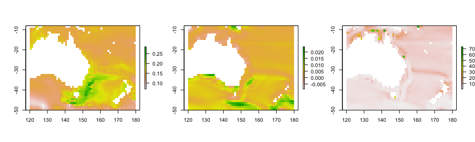

```r
rtrend <- rgrad <- rvocc <- raster(sst)
rgrad[spatx$icell] <- spatx$NS
rtrend[slopedat$icell] <- slopedat$slope
rvocc[velodf$icell] <- velodf$velocity

par(mfrow = c(1,3))
plot(rtrend)
plot(rgrad)
plot(rvocc)
```

## Citing this package and the methods used herein

Citations for the methods can be found here:

```r
citation("vocc")
```

```
##
##
##   Christopher Brown and David Schoeman (2018). vocc: Functions for
##   Calculating the Velocity of Climate Change. R package version
##   0.1.
##
## A BibTeX entry for LaTeX users is
##
##   @Manual{,
##     title = {vocc: Functions for Calculating the Velocity of Climate Change},
##     author = {Christopher Brown and David Schoeman},
##     year = {2018},
##     note = {R package version 0.1},
##   }
```

Which accompanies the publication:

Climate velocity can inform conservation planning and action in a warming world (Submitted) Isaac Brito-Morales, Jorge Garcia Molinos, Dave S. Schoeman, Michael T. Burrows, Elvira S. Poloczanska, Christopher J. Brown, Simon Ferrier, Tom D. Harwood, Carissa J. Klein, Eve McDonald-Madden, Pippa J. Moore, John M Pandolfi, James E. Watson, Amelia S. Wenger and Anthony J. Richardson

The description of the basic velocity method is found in:

Loarie SR, Duffy PB, Hamilton H, Asner GP, Field CB, Ackerly DD. The velocity of climate change. 2009. Nature. 24:1052-5.

More information about the HadISST data:

Rayner, N. A.; Parker, D. E.; Horton, E. B.; Folland, C. K.; Alexander, L. V.; Rowell, D. P.; Kent, E. C.; Kaplan, A. (2003) Global analyses of sea surface temperature, sea ice, and night marine air temperature since the late nineteenth century J. Geophys. Res.Vol. 108, No. D14, 4407 10.1029/2002JD002670